# LA.6: Examining Relationships (10 points)

# Overview

**Before you start** this assignment, watch [this video](https://youtu.be/08uylSp-CuI) to understand the logic of hypothesis testing. In LA.5, we visualize the relationship between two variables. Whereas graphs can be informative, we do not know for sure whether a relationship is real or not. In hypothesis testing, we use statistical tests to help us conclude whether there is a “meaningful” relationship between two variables. By “meaningful,” we mean “statistically significant,” a term you’ll hear a lot.

We use different statistical tests depending on the nature of the independent (or predictor, explanatory) variable and the dependent (or outcome, response) variable. These tests include correlation, t-tests, ANOVA, and Chi-square tests. It is important to correctly identify the type of variables involved in a hypothesis (or research question) so that you can choose the right test. Each produces a **test statistic** and an associated probability value (**p-value**), which helps us determine whether the result is **statistically significant**. The video provides the basic background knowledge, and the “Hints” for Question 2 is also very useful for you to complete this assignment.

# Data

Use the Utilities.csv data set to complete this assignment. This data set contains a random sample of 117 utility bills for the following variables:

- `month`: month (coded as a number)
- `day`: day of month on which bill was calculated
- `year`: year of bill
- `temp`: average temperature ($^{\circ}$F) for billing period
- `kwh`: electricity usage (kwh)
- `ccf`: gas usage (ccf)
- `thermsPerDay`: a numeric vector
- `billingDays`: number of billing days in billing period
- `totalbill`: total bill (in dollars)
- `gasbill`: gas bill (in dollars)
- `elecbill`: electric bill (in dollars)
- `notes`: notes about the billing period
- `donate`: (yes or no) did the person add money to their bill to be donated to Operation Fuel, a charity providing heat to families/small businesses in need

# Instructions

In this assignment, we use this data to test the following hypothesis:

H1: The total monthly bill varies with season.  
(The counterpart null hypothesis, H0: The total monthly bill stays the same across all seasons.)

Follow the steps outlined below to complete this hypothesis testing.

## Step 1

### Question 1

1. Load the Utilities.csv data set and re-familiarize yourself with the variables.
2. We first need to create a variable `season` based on `month` (the same as the first part of Q7 in [LA.5](https://yesuncomm.github.io/comm3710/LA/LA.5.html)). Have the variable equal “winter” if the bill was from December, January, or February. Have the variable equal “spring” if the bill was from March, April, or May. Have the variable equal “summer” if the bill was from June, July, or August. Have the variable equal “fall” if the bill was from September, October, or November.
   - Include the codes that you used to import the data and create `season` in your R file.
   - Include the frequency table for `season` in your PDF submission.

### Hints

Use the skills you learned in data management (e.g., subsetting in Q2b, LA.4) to create a new variable called `season` according to the instructions. Note that `season` is a categorical, character variable here. Also pay attention to the condition argument: for each season, the three months are combined by the logical operator “or”, which translates to `|` in R (See our [Help Guide](https://rpubs.com/yesun/716728), Section 2.5).

## Step 2

### Question 2

Choose an appropriate statistical test to determine whether the total monthly bill varies with season. Answer these questions:

1. Which is the independent variable? Which is the dependent variable? Is the independent variable categorical or quantitative? Is the dependent variable categorical or quantitative?
2. Based on your answer above, what statistical test did you use?
3. What is the **test statistic** and the **probability value** associated with that test statistic?
4. Does total monthly bill vary significantly with season?
   - Include the codes that you used for the statistical test in your R file.
   - Include the answers to all these questions in your PDF submission.

### Hints

#### 1. Selecting a statistical test

First, identify whether the independent and dependent variables are quantitative/continuous or categorical (see LA.2 if you need a reminder). Then, use the chart below to select a statistical test.

*Note*: You will have to replace `dataframe`, `ind_var`, and `dep_var` in the R commands listed in the chart with your own data frame, independent variable, and dependent variable names. In red are functions or arguments that should not be replaced. (Click here to see [a larger picture](https://yesuncomm.github.io/comm3710/LA/LA.6_chart.png)).

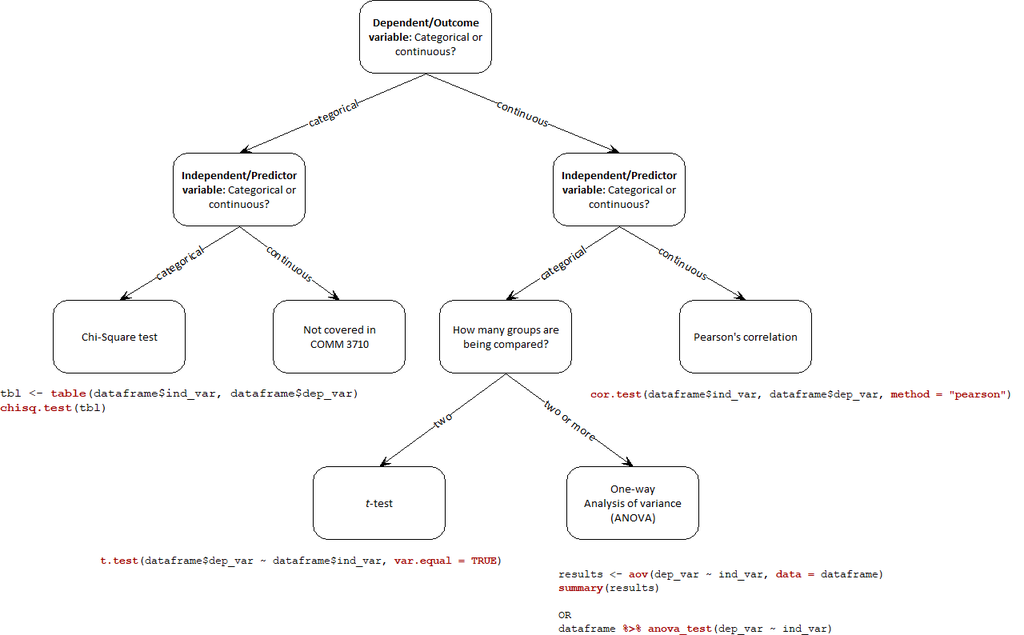

#### 2. Test statistics and *p*-values

Second, for each test, you will need to identify and report the **test statistics and *p*-values**.

| Hypothesis Test | Test Statistic Name | Test Statistic Symbol |
| --- | --- | --- |
| Chi-squared test | Chi-squared value | $\chi^2$ |
| t-test | *t*-value | $t$ |
| ANOVA | *F*-value | $F$ |
| Pearson’s correlation | Pearson’s correlation coefficient | $r$ |

The images below identify the test statistics and *p*-values in R output. Be sure to report the correct values. If $p < 0.05$, then we conclude that the relationship is statistically significant.

For Chi-square:

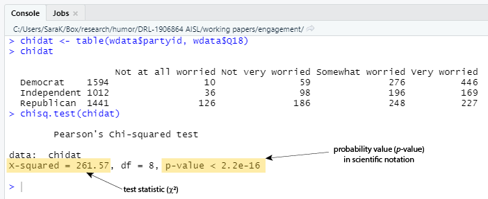

For t test:

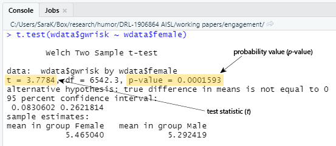

For ANOVA:

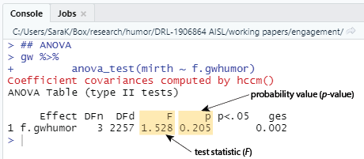

For correlation:

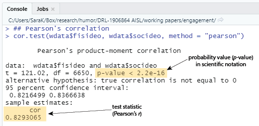

## Step 3

Submit the following on Canvas:

1. A **.R file** containing all the codes used to complete this assignment. This document should include comments that explain your commands.
2. A **PDF file** containing the answers to each question–clearly label the answers with the question number.

# Resources

| I need help with… | Link |
| --- | --- |
| The basics of R | https://rpubs.com/yesun/Comm3710_helpwithR |
|  | https://sarakyeo.github.io/COMM-3710-bookdown/docs/ |
| Hypothesis testing | https://youtu.be/08uylSp-CuI |
| Analysis of variance (ANOVA) | https://youtu.be/2uQCUBtqCfM |
| Chi-square test of independence | https://youtu.be/Dnlp9vswwEk |
| Independent samples *t*-test | https://youtu.be/ANMuuq502rE?t=590 |
| Correlation | https://youtu.be/lf4HfHx2ASs |